# R Tutorial: Summarizing Univariate Data

# Learning Objectives:

- Create a frequency table of counts and proportions for categorical data
- Create bar and pie charts
- Compute summary statistics for quantitative data
- Create histograms and stem-and-leaf plots

# Example data

Read the “coffee.csv” file containing survey responses from 65 students about coffee consumption.

```r
coffee <- read.csv("coffee.csv")
```

# 1 Categorical Variables

Let’s examine the variable `timeCoffee`. This variable indicates the time of day that survey respondents prefer to drink coffee.

```r
time <- coffee$timeCoffee
```

## 1.1 Summary statistics

### Frequency table

#### Counts

The `table()` function creates a frequency table of counts.

```r
counts <- table(time)
counts
```

```
## time
##           Afternoon   Evening   Morning     Night
##         7        18         8        29         3
```

We see that most respondents prefer to drink coffee in the morning (n = 29), followed by afternoon (n = 18), evening (n = 8), and night (n = 3). Seven respondents left this question blank on the survey.

#### Proportions

After creating the table object, you can compute grand totals and express frequencies as proportions or percentages.

```r
props <- prop.table(counts)
props
```

```
## time
##             Afternoon    Evening    Morning      Night
## 0.10769231 0.27692308 0.12307692 0.44615385 0.04615385
```

```r
# percentages with grand total
addmargins(props*100)
```

```
## time
##             Afternoon    Evening    Morning      Night        Sum
##  10.769231  27.692308  12.307692  44.615385   4.615385 100.000000
```

## 1.2 Graphs

### Bar chart

The function to create a bar chart is: `barplot(height, names.arg, main, xlab, ylab, col, ...)`

- **height**: vector of counts or proportions representing heights of the bars
- **names.arg** (optional): vector of names to appear under the bars
- **main** (optional): title for plot
- **xlab** (optional): title for x-axis (horizontal axis)
- **ylab** (optional): title for y-axis (vertical axis)
- **col** (optional): colour of the bars

Type `?barplot` in the console and press enter to see the documentation for this function.

We will use our previously computed frequency table of counts (`counts`) as the heights of the bars.

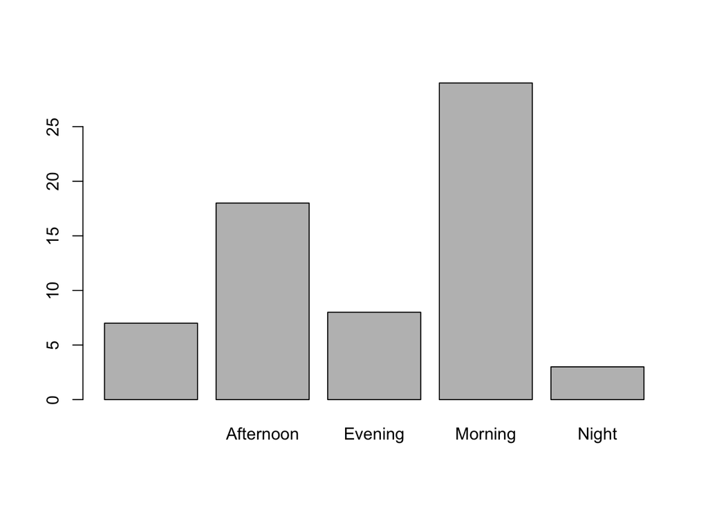

```r
barplot(height = counts)
```

#### Labeling the categories

By default, the bar chart gets the category names from the `counts` object. Let’s add a label for missing responses.

Use **names.arg** to specify a vector of category labels. The length and order the labels must be the same as the `counts` object.

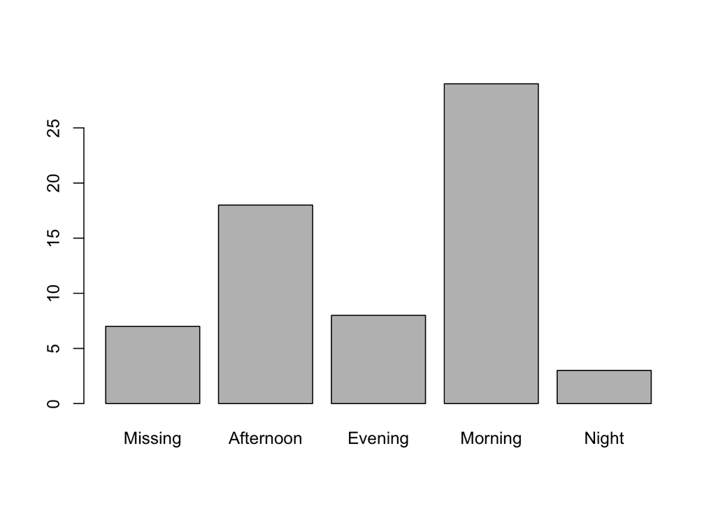

```r
barplot(height = counts,
        names.arg = c("Missing", "Afternoon", "Evening", "Morning", "Night"))
```

Alternatively, we can alter the names of `counts` directly. This is preferred since we will likely re-use `counts` later and we want our labeling to carry-through to other plots and summaries.

```r
# examine existing names of counts
names(counts)
```

```
## [1] ""          "Afternoon" "Evening"   "Morning"   "Night"
```

```r
# replace first label ("") with "missing"
names(counts)[1] <- "Missing"

# new names
names(counts)
```

```
## [1] "Missing"   "Afternoon" "Evening"   "Morning"   "Night"
```

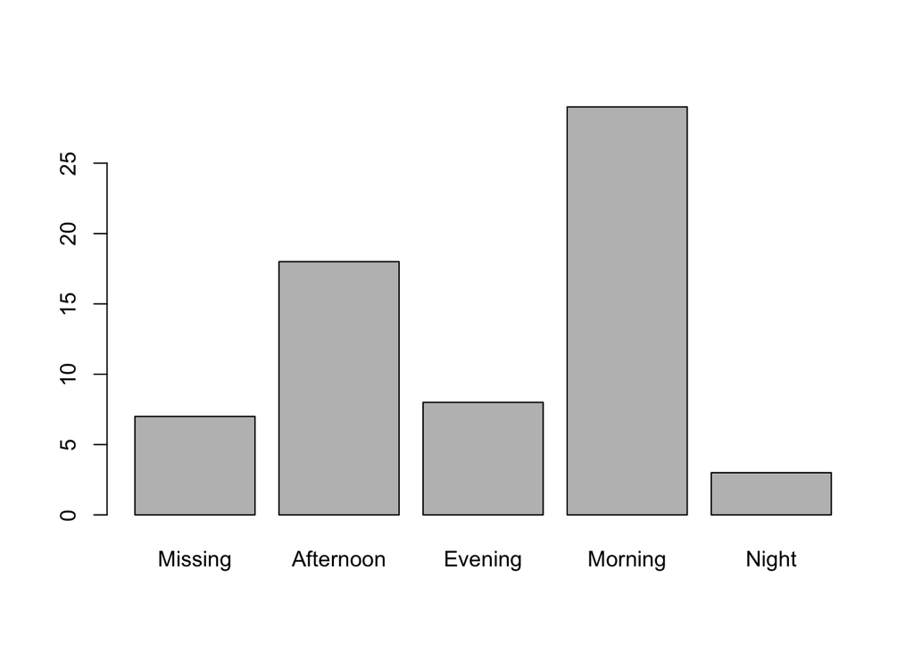

```r
barplot(counts)
```

#### Ordering the categories

The `counts` objects also determines the order that categories appear on the horizontal axis.

Let’s rearrange the categories from smallest to largest frequency.

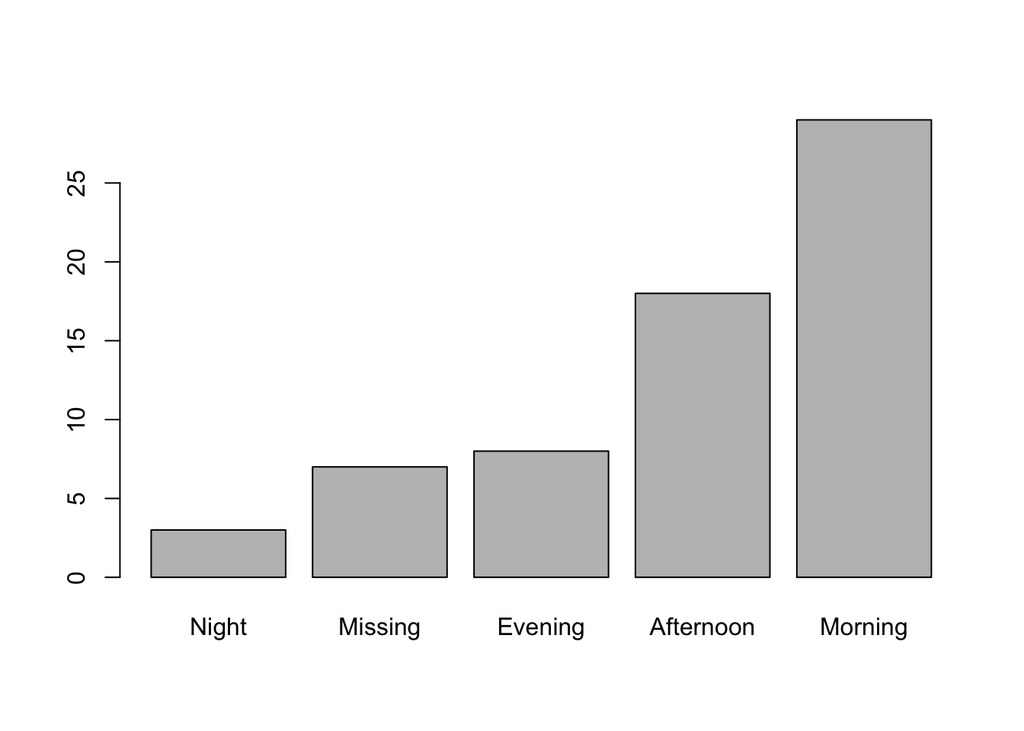

```r
counts <- sort(counts)
barplot(counts)
```

We might prefer to arrange the categories by time since the variable is ordinal. Recall that we can select values from vectors by their names. For example, the code `counts["Missing"]` will return the counts for the Missing category. The code `counts[c("Missing", "Night")]` will return the counts for the categories Missing and Night.

We can rearrange the counts object by listing the categories inside a vector `c()`in the order we wish them to appear.

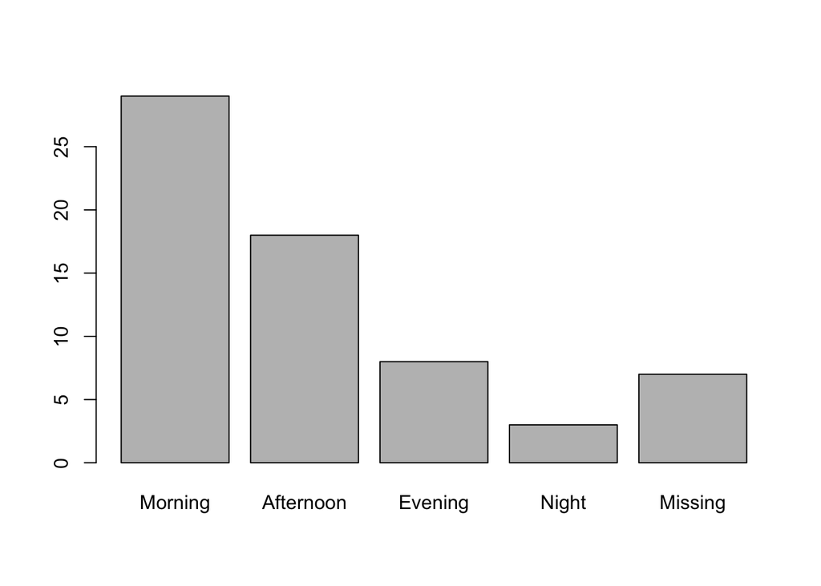

```r
counts <- counts[c("Morning", "Afternoon", "Evening", "Night", "Missing")]
barplot(counts)
```

#### Other options

We can also plot percentages and customize other features of the plot.

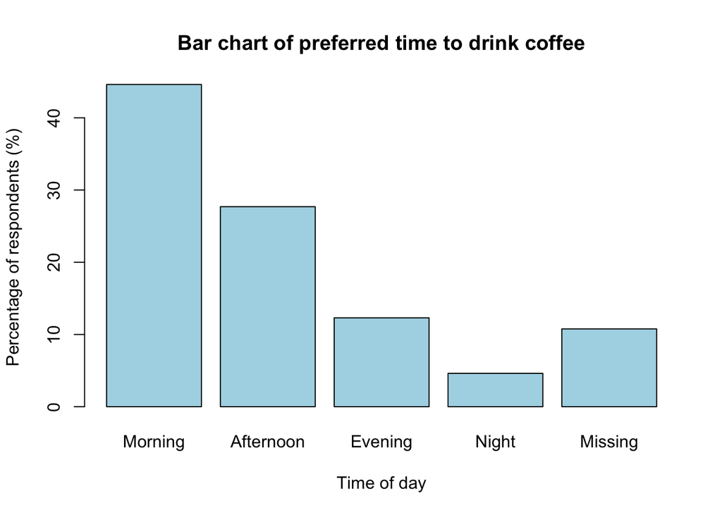

```r
barplot(height = prop.table(counts)*100,
        main = "Bar chart of preferred time to drink coffee",
        xlab = "Time of day",
        ylab = "Percentage of respondents (%)",
        col = "lightblue")
```

### Pie chart

The function to create a pie chart is: `pie(x, labels, clockwise, main, col, ...)`

- **x**: vector of counts or proportions representing areas of the pie slices
- **labels** (optional): vector of names to label the slices
- **clockwise** (optional): `TRUE` or `FALSE` indicating whether slices are drawn clockwise (`FALSE` by default)
- **main** (optional): title for plot
- **col** (optional): vector of colours for the slices

Type `?pie` in the console and press enter to see the documentation for this function.

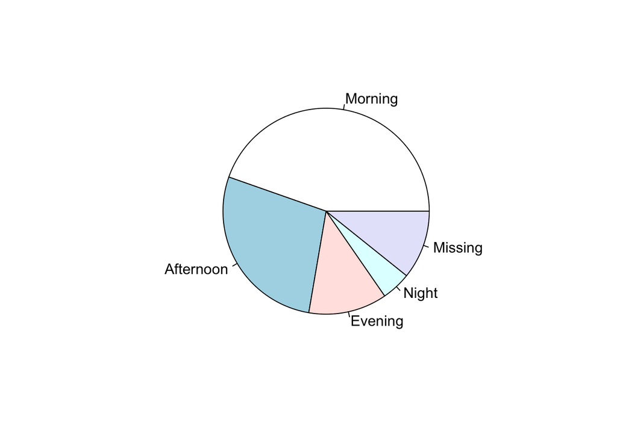

```r
pie(counts)
```

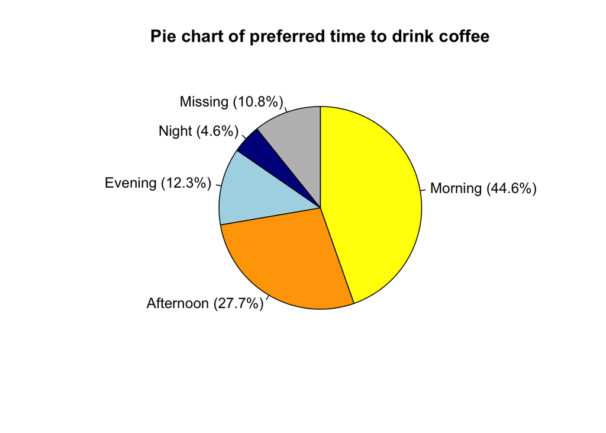

```r
pie(x = counts,
    labels = c("Morning (44.6%)",
               "Afternoon (27.7%)",
               "Evening (12.3%)",
               "Night (4.6%)",
               "Missing (10.8%)"),
    clockwise = TRUE,
    main = "Pie chart of preferred time to drink coffee",
    col = c("yellow", "orange", "lightblue", "darkblue", "grey"))
```

# 2 Quantitative Variables

Let’s examine the variable `age`. We will exclude missing values (`NA`).

```r
age <- na.omit(coffee$age)
```

## 2.1 Summary statistics

For numeric data, `summary()` will output the 5-number summary (min, Q1, median, Q3, max) and the mean.

```r
summary(age)
```

```
##    Min. 1st Qu.  Median    Mean 3rd Qu.    Max.
##   17.00   18.00   19.00   20.42   21.00   35.00
```

### Measures of center

```r
mean(age)
median(age)
```

[output not shown]

### Measures of spread

```r
sd(age)   # standard deviation
var(age)  # variance
IQR(age)  # interquartile range
```

[output not shown]

### Percentiles, minimum, and maximum

```r
min(age)              # minimum
max(age)              # maximum
quantile(age, 0.1)    # 10th percentile
quantile(age, 0.25)   # 25th percentile (Q1)
quantile(age, 0.75)   # 75th percentile (Q3)
```

[output not shown]

## 2.2 Graphs

### Histogram

The function to create a histogram is: `hist(x, breaks, main, xlab, ylab, ...)`

- **x**: vector of numeric values
- **breaks** (optional): the desired number of bins (output may vary depending on the data)
- **main, xlab, ylab** (optional): title for plot, x-axis, and y-axis
- **xlim, ylim** (optional): range of x and y values to show on the axes
- **col** (optional): colour of the bars

Type `?hist` in the console and press enter to see the documentation for this function.

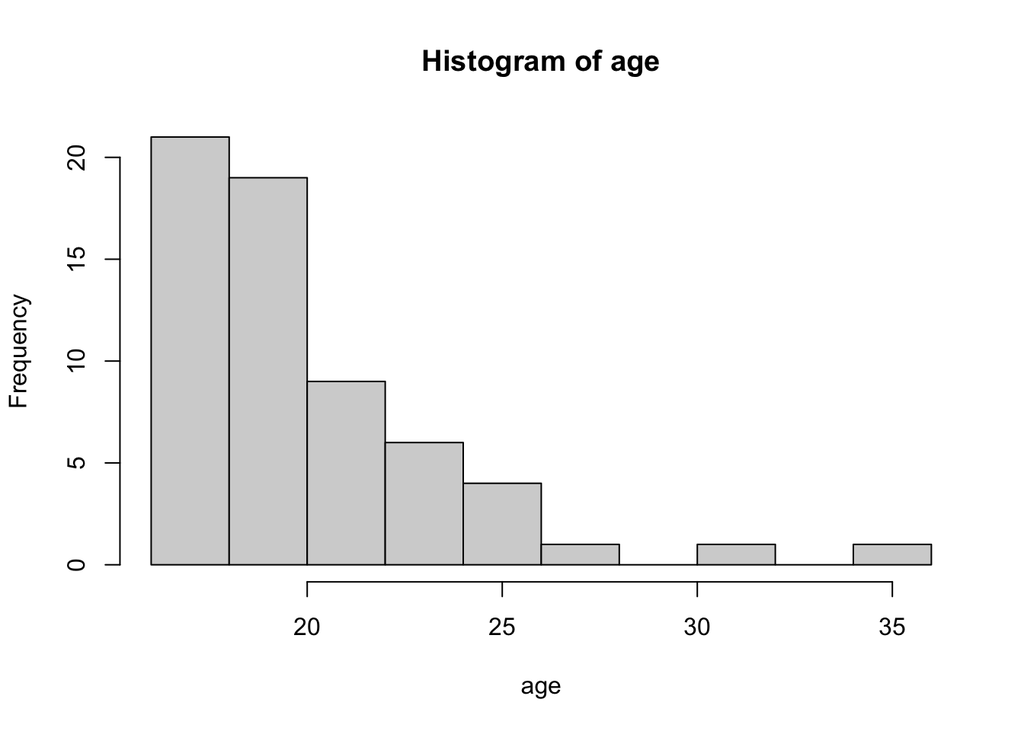

```r
hist(age)
```

Let’s customize this plot.

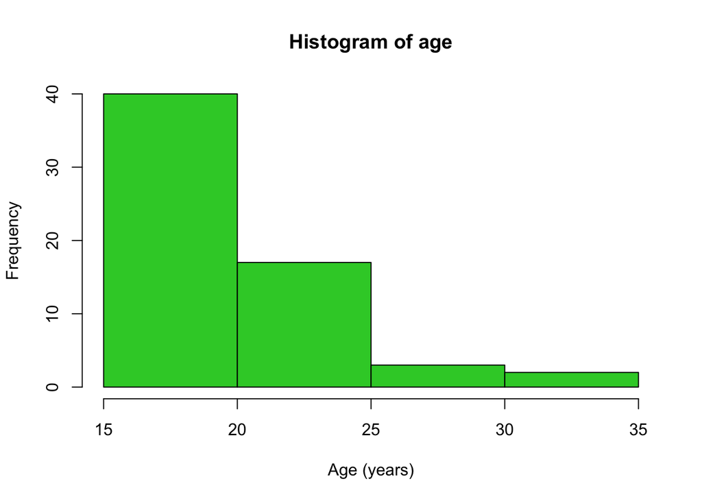

```r
hist(x = age,
     breaks = 5,
     xlab = "Age (years)",
     xlim = c(15, 35),
     col = "limegreen")
```

### Stem and leaf

The function to create a stem and leaf plot is: `stem(x, scale, ...)`

- **x**: vector of numeric values
- **scale** (optional): a number controlling the plot length

Type `?stem` in the console and press enter to see the documentation for this function.

```r
stem(age)
```

```
##
##   The decimal point is at the |
##
##   16 | 0000
##   18 | 000000000000000000000000000000
##   20 | 00000000000000
##   22 | 00000
##   24 | 0000
##   26 | 000
##   28 |
##   30 | 0
##   32 |
##   34 | 0
```

R will automatically compute the most appropriate stems for the data. Use **scale** to change them.

```r
# Values of scale > 1 will make the plot longer (and therefore the stems smaller)
stem(age, scale = 2)
```

```
##
##   The decimal point is at the |
##
##   17 | 0000
##   18 | 00000000000000000
##   19 | 0000000000000
##   20 | 000000
##   21 | 00000000
##   22 | 0
##   23 | 0000
##   24 | 00
##   25 | 00
##   26 | 00
##   27 | 0
##   28 |
##   29 |
##   30 |
##   31 | 0
##   32 |
##   33 |
##   34 |
##   35 | 0
```

```r
# Values of scale < 1 will make the plot shorter (and therefore the stems larger)
stem(age, scale = 0.5)
```

```
##
##   The decimal point is 1 digit(s) to the right of the |
##
##   1 | 7777888888888888888889999999999999
##   2 | 000000111111112333344
##   2 | 55667
##   3 | 1
##   3 | 5
```

# Exercises

1. Create a frequency table of proportions for `city`.
2. Create a bar chart of counts for `city`.
   - Arrange the cities from least to most frequent.
   - The category labels are too long to appear without overlapping. Rotate the labels by including the argument `las = 2` inside the `barplot()` function.
   - Expand the margins of the plotting region so that the labels are not cut off. Before creating your bar chart, run `par(mar=c(10,4,4,4))` as a separate line of code to expand the bottom margin.
3. Create a pie chart for whether students drink coffee or not (`drinkCoffee`).
   - Exclude missing values by generating your table of counts with `table(coffee$drinkCoffee)[c("Yes", "No")]`.
   - Label the slices with percent frequencies.
   - Create a meaningful title.
   - Customize the slice colours.
4. Compute the 5-number-summary and the standard deviation for dollars spent on coffee per week (`dollarsCoffee`) among students living in Vancouver.
   - Use `van <- coffee[coffee$city %in% "Vancouver", ]` to subset the data
   - Some functions will return `NA` if there are missing values. Trying including `na.rm = TRUE` inside your function to ignore missing values when computing summary statistics.
5. Create a histogram of dollars spent on coffee among students living in Vancouver.
6. Create a stem and leaf plot of dollars spent on coffee among students living in Vancouver. Use `scale = 0.25`.

# Solutions

```r
# 1. Create a frequency table of proportions for `city`.
prop.table(table(coffee$city))
```

```
##
##      Abbotsford         Burnaby         Langley     Maple Ridge New Westminster
##      0.01538462      0.06153846      0.03076923      0.01538462      0.03076923
## North Vancouver        Richmond          Surrey       Vancouver
##      0.01538462      0.24615385      0.15384615      0.43076923
```

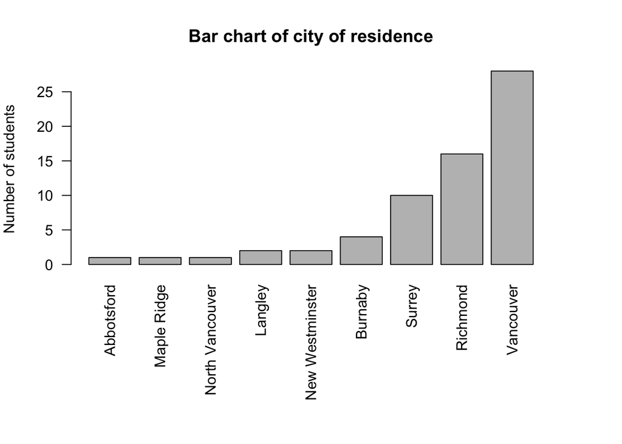

```r
# 2. Create a bar chart of counts for `city`. Arrange the cities from least to most frequent.
par(mar=c(10,4,4,4))
barplot(height = sort(table(coffee$city)),
        las = 2,
        main = "Bar chart of city of residence",
        ylab = "Number of students")
```

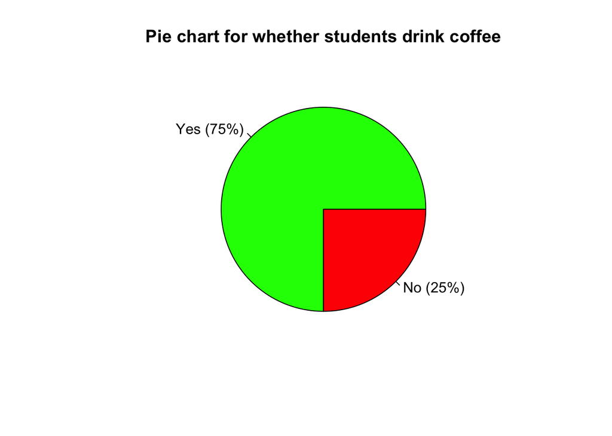

```r
# 3. Create a pie chart for whether students drink coffee or not (`drinkCoffee`).
pie(x = table(coffee$drinkCoffee)[c("Yes", "No")],
    labels = c("Yes (75%)", "No (25%)"),
    main = "Pie chart for whether students drink coffee",
    col = c("green", "red"))
```

```r
# 4. Compute the 5-number-summary and the standard deviation for dollars spent on coffee among students living in Vancouver.
van <- coffee[coffee$city %in% "Vancouver", ]
summary(van$dollarsCoffee)
```

```
##    Min. 1st Qu.  Median    Mean 3rd Qu.    Max.    NA's
##   0.000   2.500   5.000   6.607  10.000  20.000       1
```

```r
paste0("Standard deviation = ", round(sd(van$dollarsCoffee, na.rm=TRUE), 4))
```

```
## [1] "Standard deviation = 5.7399"
```

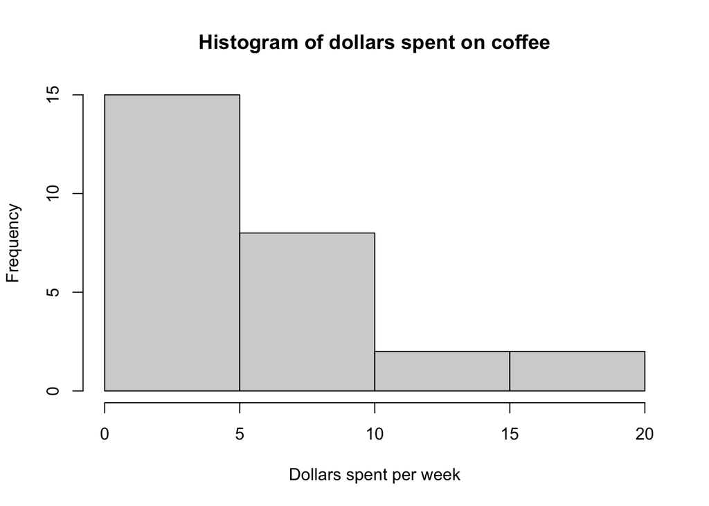

```r
# 5. Create a histogram of dollars spent on coffee among students living in Vancouver.
hist(van$dollarsCoffee, main = "Histogram of dollars spent on coffee",
     xlab = "Dollars spent per week")
```

```r
# 5. Create a stem and leaf plot of dollars spent on coffee among students living in Vancouver.
stem(van$dollarsCoffee, scale = 0.25)
```

```
##
##   The decimal point is 1 digit(s) to the right of the |
##
##   0 | 00000014444555577
##   1 | 00000025
##   2 | 00
```